# Midterm

### Assess the performance of your model in test

Print the performance of your best model in test and make a plot to visualize the relationship between raw and predicted `y` in your test set.

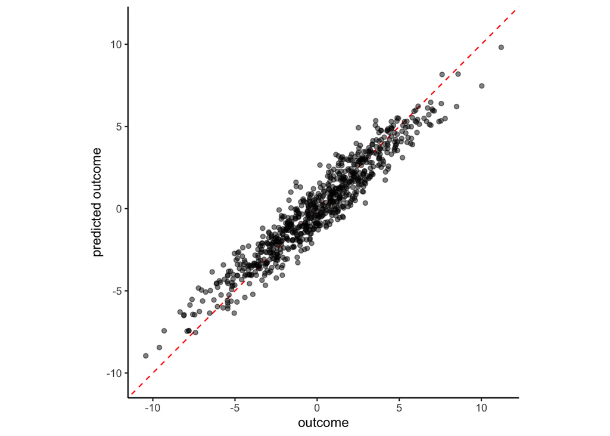

```r
# Fit best Model
fit_glmnet <- linear_reg(penalty = select_best(fits_glmnet)$penalty,
                         mixture = select_best(fits_glmnet)$mixture) |>
  set_engine("glmnet") |>
  fit(y ~ ., data = feat_trn_3)

# Visualize
predictions <- predict(fit_glmnet, new_data = feat_trn_3)
plot_truth(truth = feat_trn_3$y, estimate = predictions$.pred)
```

```r
# RMSE
glmnet_rmse_trn <- rmse_vec(truth = feat_trn_3$y,
         estimate = predict(fit_glmnet, feat_trn_3)$.pred) # 1.01
glmnet_rmse_test <- rmse_vec(truth = feat_test_3$y,
         estimate = predict(fit_glmnet, feat_test_3)$.pred) # 0.9326
```

#### **3.2) Does your test RMSE seem like a good fit to you? What is the worst value you might have expected for RMSE and why?**

*Yes my test RMSE seems like a good fit because the test and training error are relatively similar and low. This means the model was not overfit to the training data and able to perform well in test data. The worst value I may have expected for RMSE would be something drastically higher than 1.01 (training set RMSE).*

#### **3.3) Explain why you see a difference between your best model’s RMSE in training vs test. Give one example of something that could INCREASE this difference**

*The model is going to perform differently with each new set of data, so no two sets will have the exact same RMSE. However, if the training set RMSE is a lot lower than the test set’s, it could be the result of overfitting. Some things that could increase overfitting in the training set (and thus increase the difference in RMSE) would be a small training sample or a complex model.*

**Congrats on finishing your first take home exam!!!!**